# Lab 2. Regresión Lineal, pt I

### 1. Librerías

La función **library()** se utiliza para cargar bibliotecas, o grupos de funciones y conjuntos de datos que no están incluidos en la distribución de la base R. Funciones básicas que realizan una regresión lineal de mínimos cuadrados y otros análisis simples vienen estándar con la distribución de la base, pero las funciones más exóticas requieren bibliotecas adicionales. Aquí cargamos el paquete **MASS**, que es una gran la recopilación de conjuntos de datos y funciones. También cargamos el paquete **ISLR**, que incluye los conjuntos de datos asociados a este libro.

```r
library (MASS)
library (ISLR)
```

Si recibe un mensaje de error al cargar cualquiera de estas bibliotecas, probablemente indica que la biblioteca correspondiente no ha sido instalada todavía en tu sistema. Algunas bibliotecas, como **MASS**, vienen con **R** y no necesitan se instalen por separado en su ordenador. Sin embargo, otros paquetes, como **ISLR**, deben ser descargados la primera vez que se usen. Esto puede hacerse directamente desde dentro de **R**. Por ejemplo, en un sistema Windows, seleccione la opción **Install.packages** en la pestaña **Packages**. Después de seleccionar cualquier sitio espejo, un aparecerá una lista de los paquetes disponibles. Simplemente seleccione el paquete que desea instalar y R descargará automáticamente el paquete. Alternativamente, este puede hacerse en la línea de comandos R mediante **install.packages(“ISLR”)**. Esta instalación sólo tiene que hacerse la primera vez que se usa un paquete. Sin embargo, la función library() debe ser llamada cada vez que se desee utilizar un determinado paquete.

### 2. Escribir Funciones

```r
LoadLibraries
LoadLibraries()
```

Ahora creamos la función. Observe que los símbolos **+** son impresos por **R** y no debe ser escrito a máquina. El símbolo **{** informa a **R** que los múltiples comandos están a punto de ser introducidos. Al pulsar Enter después de escribir **{** hará que **R** imprima el símbolo **+**. Podemos entonces introducir tantos comandos como queramos, pulsando Enter después de cada uno. Finalmente el símbolo **}** informa a **R** que no hay más órdenes será ingresado.

```r
#Function le dice al sistema que estamos creando una función corchetes son para llamar a casa una de las librerías
LoadLibraries<-function (){
  library(ISLR) ;
  library(MASS) ;
  print("The libraries have been loaded.")}
```

Ahora, si tecleamos **LoadLibraries**, **R** nos dirá qué hay en la función.

```r
#Al describir la función aparecerá que viene dentro de ella
LoadLibraries
```

```
## function (){
##   library(ISLR) ;
##   library(MASS) ;
##   print("The libraries have been loaded.")}
```

Si llamamos a la función, las bibliotecas se cargan y la declaración de impresión es la salida.

```r
#Escrito así corre la función
LoadLibraries()
```

[output not shown]

### 3. Regresión Lineal Simple

La biblioteca del **MASS** contiene el conjunto de datos de **Boston**, que registra la **medv**(media valor de la casa) para 506 vecindarios alrededor de Boston. Buscaremos predecir **medv** utilizando 13 predictores como **rm** (número medio de habitaciones por casa), **age** (edad media de las casas), y **lstat** (porcentaje de hogares con baja situación socioeconómica).

```r
head(Boston )
```

```
##      crim zn indus chas   nox    rm  age    dis rad tax ptratio  black lstat
## 1 0.00632 18  2.31    0 0.538 6.575 65.2 4.0900   1 296    15.3 396.90  4.98
## 2 0.02731  0  7.07    0 0.469 6.421 78.9 4.9671   2 242    17.8 396.90  9.14
## 3 0.02729  0  7.07    0 0.469 7.185 61.1 4.9671   2 242    17.8 392.83  4.03
## 4 0.03237  0  2.18    0 0.458 6.998 45.8 6.0622   3 222    18.7 394.63  2.94
## 5 0.06905  0  2.18    0 0.458 7.147 54.2 6.0622   3 222    18.7 396.90  5.33
## 6 0.02985  0  2.18    0 0.458 6.430 58.7 6.0622   3 222    18.7 394.12  5.21
##   medv
## 1 24.0
## 2 21.6
## 3 34.7
## 4 33.4
## 5 36.2
## 6 28.7
```

```r
names(Boston )
```

```
##  [1] "crim"    "zn"      "indus"   "chas"    "nox"     "rm"      "age"
##  [8] "dis"     "rad"     "tax"     "ptratio" "black"   "lstat"   "medv"
```

Para saber más sobre el conjunto de datos, podemos escribir **?Boston**.

Empezaremos usando la función **lm()** para ajustar una simple regresión lineal con el **medv** como respuesta y el **lstat** como predictor. El modelo básico La sintaxis es **lm(y~x,data)**, donde **y** es la respuesta, **x** es el predictor, y es el conjunto de datos en el que se mantienen estas dos variables.

```r
lm.fit <-lm(medv~lstat)
#Regresión lineal de
```

El comando causa un error porque **R** no sabe dónde encontrar las variables Medv e Istat. La siguiente línea le dice a R que las variables son en Boston. Si adjuntamos Boston, la primera línea funciona bien porque R ahora reconoce las variables.

```r
lm.fit <-lm(medv~lstat ,data=Boston )
attach (Boston )
lm.fit <-lm(medv~lstat)
```

Si tecleamos **lm.fit**, se obtiene alguna información básica sobre el modelo. Para obtener información más detallada, utilizamos **summary(lm.fit)**. Esto nos da valores p y los errores estándar de los coeficientes, así como la estadística R<sup>2</sup> y F-estadística para el modelo.

```r
lm.fit
```

```
##
## Call:
## lm(formula = medv ~ lstat)
##
## Coefficients:
## (Intercept)        lstat
##       34.55        -0.95
```

```r
summary (lm.fit)
```

```
##
## Call:
## lm(formula = medv ~ lstat)
##
## Residuals:
##     Min      1Q  Median      3Q     Max
## -15.168  -3.990  -1.318   2.034  24.500
##
## Coefficients:
##             Estimate Std. Error t value Pr(>|t|)
## (Intercept) 34.55384    0.56263   61.41   <2e-16 ***
## lstat       -0.95005    0.03873  -24.53   <2e-16 ***
## ---
## Signif. codes:  0 '***' 0.001 '**' 0.01 '*' 0.05 '.' 0.1 ' ' 1
##
## Residual standard error: 6.216 on 504 degrees of freedom
## Multiple R-squared:  0.5441, Adjusted R-squared:  0.5432
## F-statistic: 601.6 on 1 and 504 DF,  p-value: < 2.2e-16
```

Podemos usar la función **names()** para averiguar qué otras piezas de información se almacenan en **lm.fit**. Aunque podemos extraer estas cantidades por nombre, por ejemplo **lm.fit$coefficients**, es más seguro usar el extractor funciones como **coef()** para acceder a ellas.

```r
names(lm.fit )
```

```
##  [1] "coefficients"  "residuals"     "effects"       "rank"
##  [5] "fitted.values" "assign"        "qr"            "df.residual"
##  [9] "xlevels"       "call"          "terms"         "model"
```

```r
coef(lm.fit)
```

```
## (Intercept)       lstat
##  34.5538409  -0.9500494
```

Para obtener un intervalo de confianza para las estimaciones de los coeficientes, podemos usa el comando **confint()**.

```r
confint(lm.fit)
```

```
##                 2.5 %     97.5 %
## (Intercept) 33.448457 35.6592247
## lstat       -1.026148 -0.8739505
```

La función **predict()** puede utilizarse para producir intervalos de confianza y intervalos de predicción para la predicción de **medv** para un valor dado de **lstat**.

```r
#Son para el predecir el valor medio de las casas dado un valor específico de lstat
predict(lm.fit ,data.frame(lstat=c(5 ,10 ,15) ), interval = "confidence")
```

```
##        fit      lwr      upr
## 1 29.80359 29.00741 30.59978
## 2 25.05335 24.47413 25.63256
## 3 20.30310 19.73159 20.87461
```

```r
predict(lm.fit ,data.frame(lstat=c(5 ,10 ,15) ), interval = "prediction")
```

```
##        fit       lwr      upr
## 1 29.80359 17.565675 42.04151
## 2 25.05335 12.827626 37.27907
## 3 20.30310  8.077742 32.52846
```

Por ejemplo, el intervalo de confianza del 95% asociado con un valor **lstat** de 10 es (24,47, 25,63), y el intervalo de predicción del 95% es (12,828, 37,28). Como esperado, los intervalos de confianza y de predicción se centran en la el mismo punto (un valor predicho de 25.05 para el **medv** cuando el **lstat** es igual a 10), pero estos últimos son sustancialmente más amplios.

Ahora trazaremos **medv** e **lstat** junto con la menor regresión de cuadrados usando las funciones **plot()** y **abline()**.

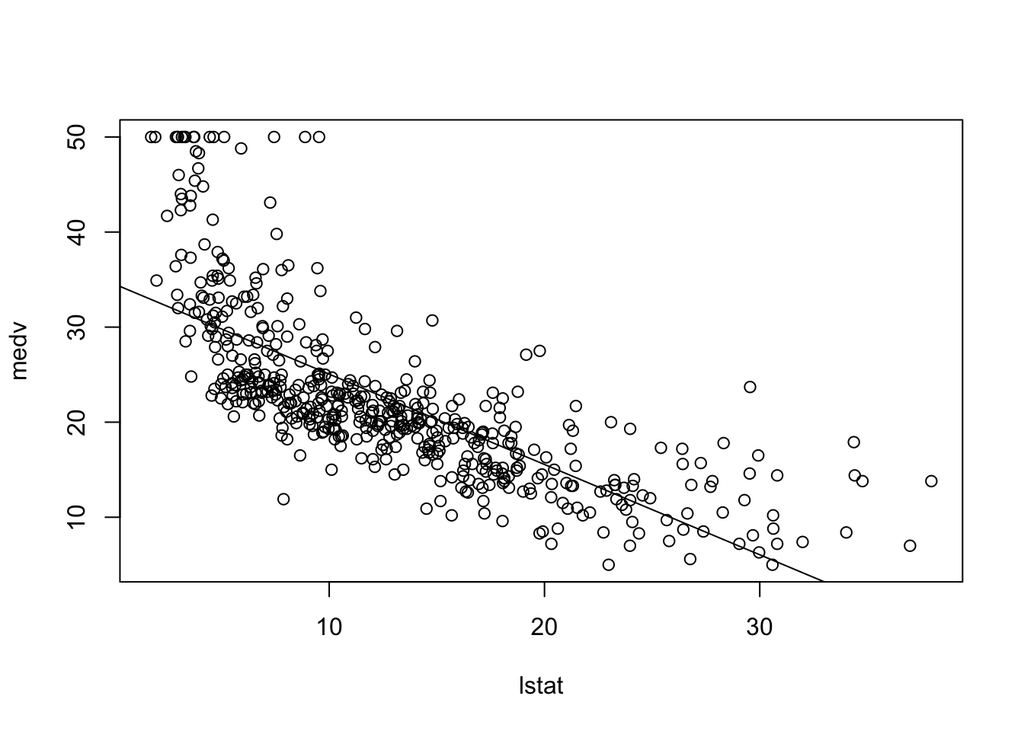

```r
plot(lstat ,medv)
abline (lm.fit)
```

Hay algunas pruebas de la no linealidad en la relación entre el **lstat** y **medv**. Exploraremos este tema más tarde en este laboratorio.

La función **abline()** puede usarse para dibujar cualquier línea, no sólo la línea de regresión de mínimos cuadrados. Para dibujar una línea con intercepción **a** y pendiente **b**, escribimos **abline(a,b)**. A continuación experimentamos con algunos ajustes adicionales para trazar líneas y puntos. El comando **lwd=3** hace que el ancho de la línea de regresión se incremente en un factor de 3; esto funciona también para las funciones **plot()** y **lines()**. También podemos usar la opción **pch** para crear diferentes símbolos de trazado.

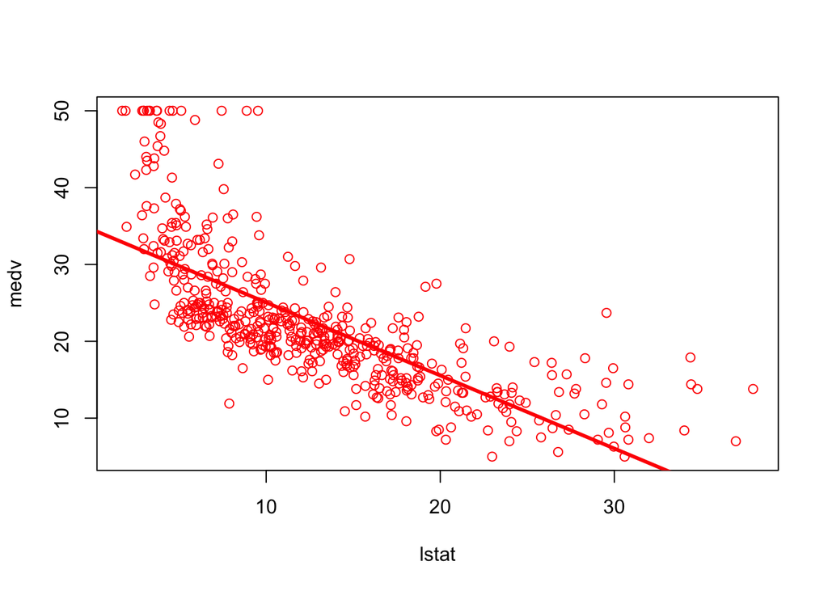

```r
plot(lstat ,medv ,col ="red ")
abline (lm.fit ,lwd =3, col ="red ")
```

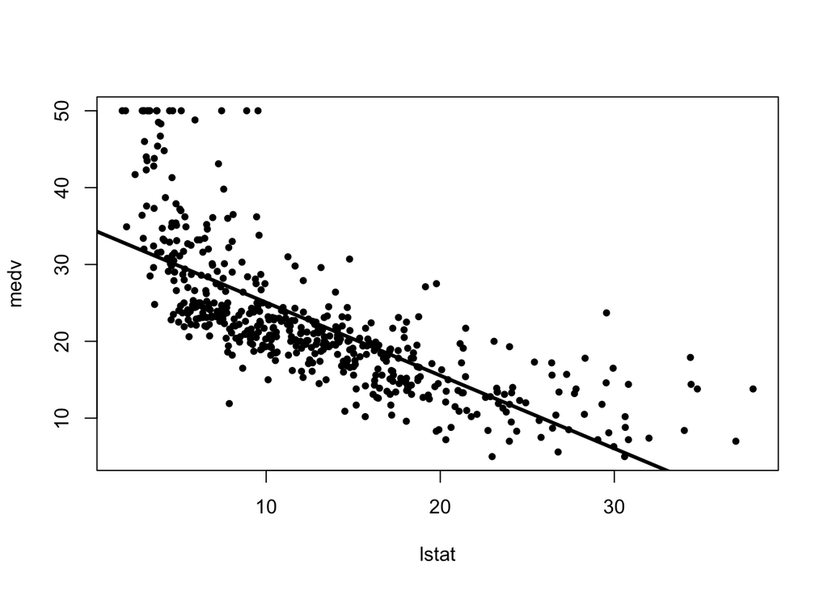

```r
#lwd para determinar grosor de la línea y col para color

plot(lstat ,medv ,pch =20)
abline (lm.fit ,lwd =3)
```

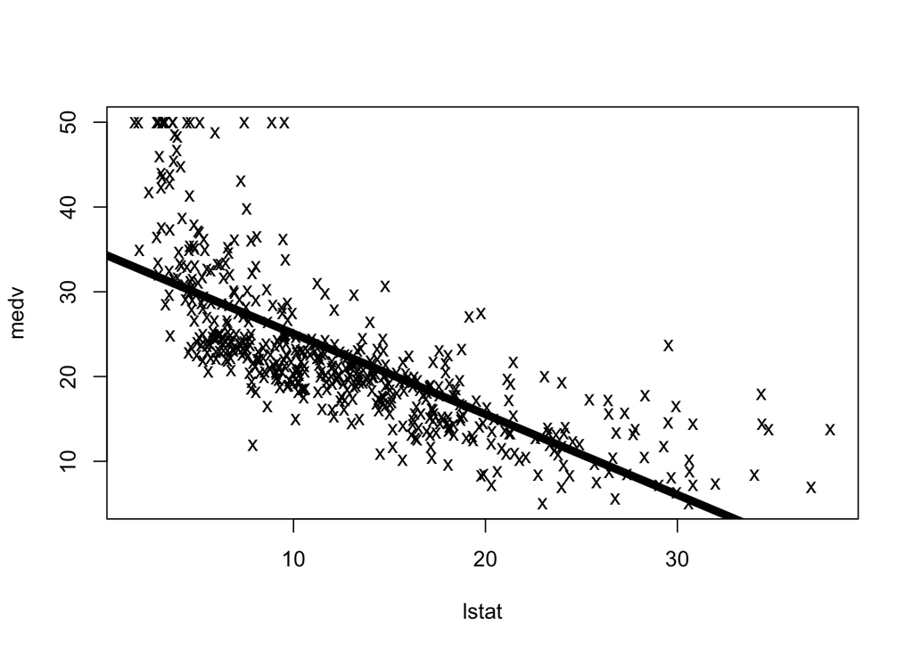

```r
#pch para pch para rellenar puntitos

plot(lstat ,medv ,pch ="x")
abline (lm.fit ,lwd =6)
```

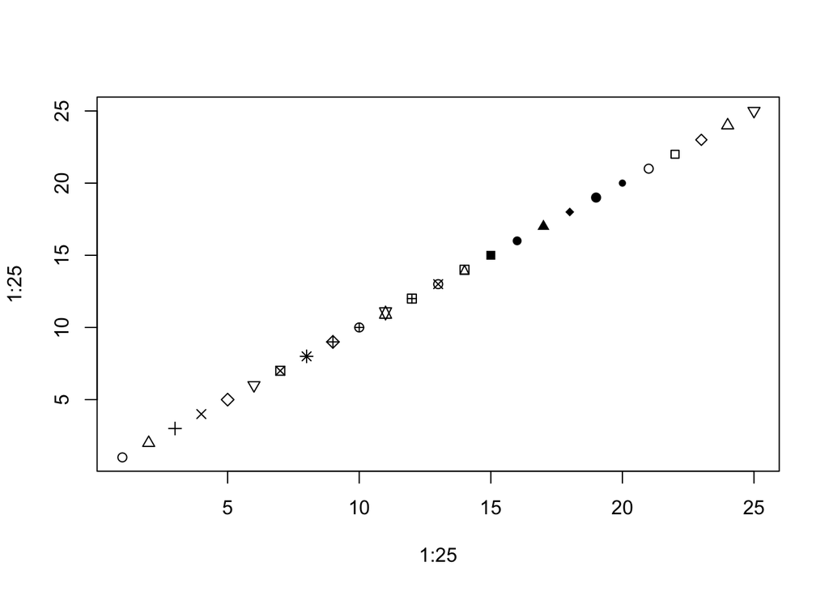

```r
#Pch para determinar la forma de los puntos con comillas

plot (1:25 ,1:25, pch =1:25)
```

A continuación examinamos algunos gráficos de diagnóstico, varios de los cuales fueron discutidos en la sección **3.3.3**. Se producen automáticamente cuatro gráficos de diagnóstico aplicando la función **plot()** directamente a la salida de **lm()**. En general, esta producirá una trama a la vez, y al pulsar Enter se generará la siguiente trama. Sin embargo, a menudo es conveniente ver las cuatro parcelas juntas. Podemos lograrlo usando la función **par()**, que le dice a **R** que divida el de la pantalla de visualización en paneles separados para que se puedan ver varios gráficos simultáneamente. Por ejemplo, **par(mfrow=c(2,2))** divide la región de los gráficos en una cuadrícula de 2 × 2 paneles.

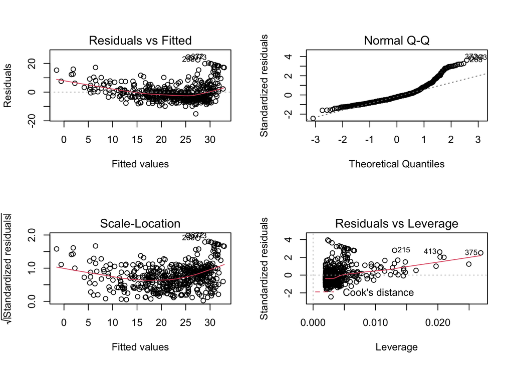

```r
par(mfrow =c(2,2))
plot(lm.fit)
```

Alternativamente, podemos calcular los residuos de un ajuste de regresión lineal usando la función **residuals()**. La función **rstudent()** devolverá el los residuos estudiados, y podemos usar esta función para trazar los residuos contra los valores ajustados.

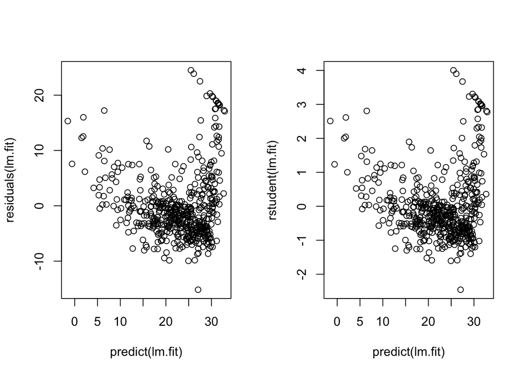

```r
par(mfrow =c(1,2))
plot(predict (lm.fit), residuals (lm.fit))
plot(predict (lm.fit), rstudent (lm.fit))
```

Sobre la base de las parcelas residuales, hay algunas pruebas de no linealidad. Las estadísticas de apalancamiento pueden ser calculadas para cualquier número de predictores usando la función **hatvalues()**.

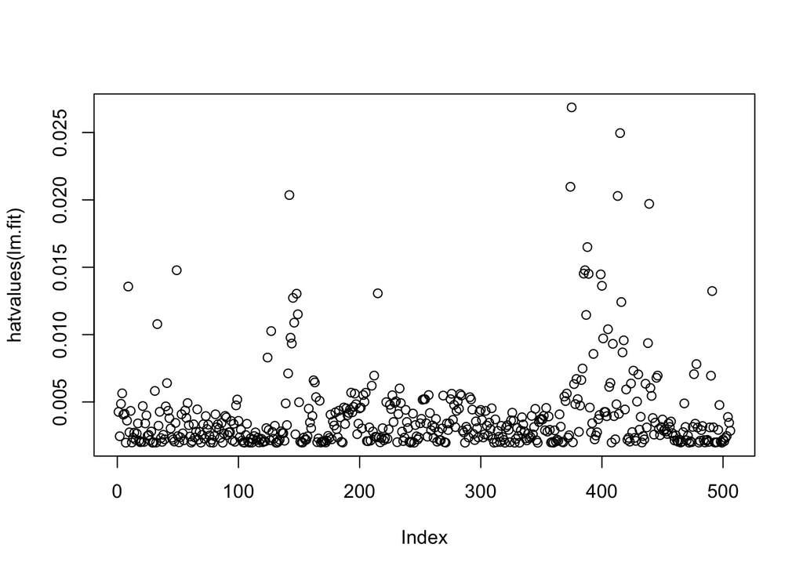

```r
#Muestra los valores más significativos para el modelo
#Son los valores que tienen más influencia en el modelo
plot(hatvalues (lm.fit ))
```

```r
which.max (hatvalues (lm.fit))
```

```
## 375
## 375
```

La función **which.max()** identifica el índice del elemento más grande de un vector. En este caso, nos dice qué observación tiene la mayor influencia estadística.

### 4. Resuelve

Esta pregunta debe responderse utilizando el conjunto de datos de Carseats.

#### a. Ajuste un modelo de regresión simple para predecir ventas usando precio.

```r
lm.fitT <-lm(Sales~Price ,data=Carseats )
summary(lm.fitT)
```

```
##
## Call:
## lm(formula = Sales ~ Price, data = Carseats)
##
## Residuals:
##     Min      1Q  Median      3Q     Max
## -6.5224 -1.8442 -0.1459  1.6503  7.5108
##
## Coefficients:
##              Estimate Std. Error t value Pr(>|t|)
## (Intercept) 13.641915   0.632812  21.558   <2e-16 ***
## Price       -0.053073   0.005354  -9.912   <2e-16 ***
## ---
## Signif. codes:  0 '***' 0.001 '**' 0.01 '*' 0.05 '.' 0.1 ' ' 1
##
## Residual standard error: 2.532 on 398 degrees of freedom
## Multiple R-squared:  0.198,  Adjusted R-squared:  0.196
## F-statistic: 98.25 on 1 and 398 DF,  p-value: < 2.2e-16
```

#### b. Proporcione una interpretación de cada coeficiente en el modelo.

```r
#Precio

#Interpretación: Como se demostró en el análisis el precio tiene un coeficiente con signo negativo lo que indica  una relación inversa con las ventas. Esto se podría explicar gracias a que entre más grande sea el precio menores serán las ventas.
```

#### c. Utilizando el modelo, obtenga intervalos de confianza del 95% para los coeficientes.

```r
confint(lm.fitT)
```

```
##                  2.5 %      97.5 %
## (Intercept) 12.3978438 14.88598655
## Price       -0.0635995 -0.04254653
```